# R Notebook

# Load dataset and libraries

```r
library(readr)
library(ggplot2) # Plotting Library
library(dplyr) # Data manipulation
library(faraway) # Data
library(car) # Linear Hypothesis Testing
library(lmreg) # One sided linear hypothesis testing
library(emmeans)

tinytex::install_tinytex(force=TRUE)
```

#Introduction

[figure not shown]

The Draco flying lizard, scientifically known as Draco volans, is a species of lizard capable of gliding through the air. These lizards belong to the family Agamidae and are native to Southeast Asia, including countries such as Malaysia, Indonesia, and the Philippines. Dracos reach about 8 inches long, including tail. They have flattened bodies, which also aid in flight, and are a mottled brown in color. The undersides of their wings are blue in males and yellow in females. They also have a flap of skin on the bottom of their necks called a dewlap. This is bright yellow in males and bluish gray in females. The flying lizard is found mainly in rain forests and tropical areas that can provide adequate number of trees for the lizard to jump from.

In this report, we are going to investigate data from Draco’s individuals living on 100 Malayan achipelago, where each row corresponds to an island.

Our variables are:

- *Count* : contains the number of flying lizards found on these plots;
- *ndvi*: index of vegetation “greenness”, with range values [-1;1], where -1 is rocky ground and. Is the maximum vegetation cover;
- *alt*: average altitude in meters; -*ants*: density of ants nests in each study plot (food sources); -*humid*: humidity in percentage; -*frog*: density of frogs in each study plot (competitors).

The main idea according to some background readings also, is that the presence of this kind of lizard, is particularly influenced by the kind of environment, in particular, being this a vulnerable species to predators, my assumption is that they use their color to camouflage their selves on rocky surrounding, from which usually there is a large amount of ants to find nutrition too.

# Methods & results

Linear regression is used to estimate the count number of lizards,

Most inclusive model:

$Y_{counts}=\beta_{ndvi}+1beta_{alt}+\beta_{ants}+\beta_{humid}+\beta_{frog}+\epsilon$

Data exploration

```r
load("Data2_DS837_F2024.rdata")
liz<-data
attach(liz)
dim(liz)
```

```
## [1] 100   6
```

```r
summary(liz)
```

```
##      counts            ndvi              alt               ants
##  Min.   :  0.00   Min.   :-0.2074   Min.   :  2.179   Min.   : 2.084
##  1st Qu.:  2.00   1st Qu.: 0.1666   1st Qu.:  8.084   1st Qu.: 7.171
##  Median :  4.00   Median : 0.3223   Median : 17.831   Median :10.356
##  Mean   : 11.81   Mean   : 0.3427   Mean   : 28.347   Mean   :12.795
##  3rd Qu.: 10.00   3rd Qu.: 0.5305   3rd Qu.: 38.386   3rd Qu.:15.765
##  Max.   :222.00   Max.   : 0.8245   Max.   :198.772   Max.   :61.229
##      humid             frog
##  Min.   :0.4989   Min.   : 88.07
##  1st Qu.:0.9911   1st Qu.: 97.05
##  Median :0.9998   Median :100.72
##  Mean   :0.9720   Mean   : 99.95
##  3rd Qu.:1.0000   3rd Qu.:102.66
##  Max.   :1.0000   Max.   :109.42
```

```r
summary(liz)
```

```
##      counts            ndvi              alt               ants
##  Min.   :  0.00   Min.   :-0.2074   Min.   :  2.179   Min.   : 2.084
##  1st Qu.:  2.00   1st Qu.: 0.1666   1st Qu.:  8.084   1st Qu.: 7.171
##  Median :  4.00   Median : 0.3223   Median : 17.831   Median :10.356
##  Mean   : 11.81   Mean   : 0.3427   Mean   : 28.347   Mean   :12.795
##  3rd Qu.: 10.00   3rd Qu.: 0.5305   3rd Qu.: 38.386   3rd Qu.:15.765
##  Max.   :222.00   Max.   : 0.8245   Max.   :198.772   Max.   :61.229
##      humid             frog
##  Min.   :0.4989   Min.   : 88.07
##  1st Qu.:0.9911   1st Qu.: 97.05
##  Median :0.9998   Median :100.72
##  Mean   :0.9720   Mean   : 99.95
##  3rd Qu.:1.0000   3rd Qu.:102.66
##  Max.   :1.0000   Max.   :109.42
```

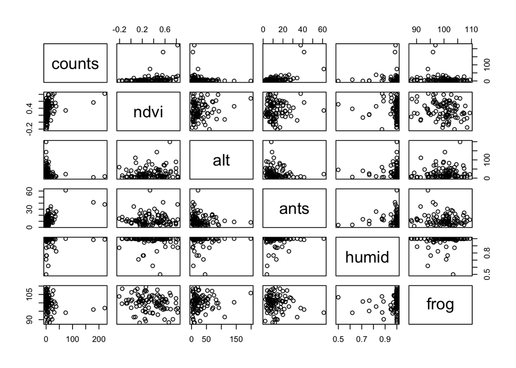

```r
plot(liz)
```

```r
head(liz)
```

|  | counts | ndvi | alt | ants | humid | frog |
| --- | --- | --- | --- | --- | --- | --- |
| 1 | 3 | 0.4926475 | 34.279667 | 7.087399 | 0.9961737 | 104.03261 |
| 2 | 1 | 0.4659495 | 24.922061 | 8.172236 | 0.9999998 | 107.75644 |
| 3 | 7 | 0.2592675 | 4.825416 | 18.907531 | 0.9997354 | 94.38309 |
| 4 | 4 | 0.1126164 | 4.258784 | 10.161320 | 1.0000000 | 108.37926 |
| 5 | 0 | 0.5139115 | 45.432653 | 3.799481 | 0.4988792 | 103.32545 |
| 6 | 23 | 0.7387078 | 5.467486 | 11.876808 | 0.8876725 | 90.19224 |

```r
# Assuming `response` is your response variable
if(any(liz$counts <= 0)) {
  liz$counts <- liz$counts + abs(min(liz$counts)) + 1
}

mod1=lm(log(counts) ~ ., data=liz)
summary(mod1)
```

```
##
## Call:
## lm(formula = log(counts) ~ ., data = liz)
##
## Residuals:
##      Min       1Q   Median       3Q      Max
## -1.48380 -0.43652  0.00873  0.57782  1.19294
##
## Coefficients:
##              Estimate Std. Error t value Pr(>|t|)
## (Intercept) -0.020954   1.701801  -0.012    0.990
## ndvi         2.284377   0.293701   7.778 9.31e-12 ***
## alt         -0.014673   0.002258  -6.497 3.87e-09 ***
## ants         0.056290   0.007732   7.280 1.00e-10 ***
## humid        1.298219   0.881277   1.473    0.144
## frog        -0.005811   0.015247  -0.381    0.704
## ---
## Signif. codes:  0 '***' 0.001 '**' 0.01 '*' 0.05 '.' 0.1 ' ' 1
##
## Residual standard error: 0.6846 on 94 degrees of freedom
## Multiple R-squared:  0.6542, Adjusted R-squared:  0.6358
## F-statistic: 35.56 on 5 and 94 DF,  p-value: < 2.2e-16
```

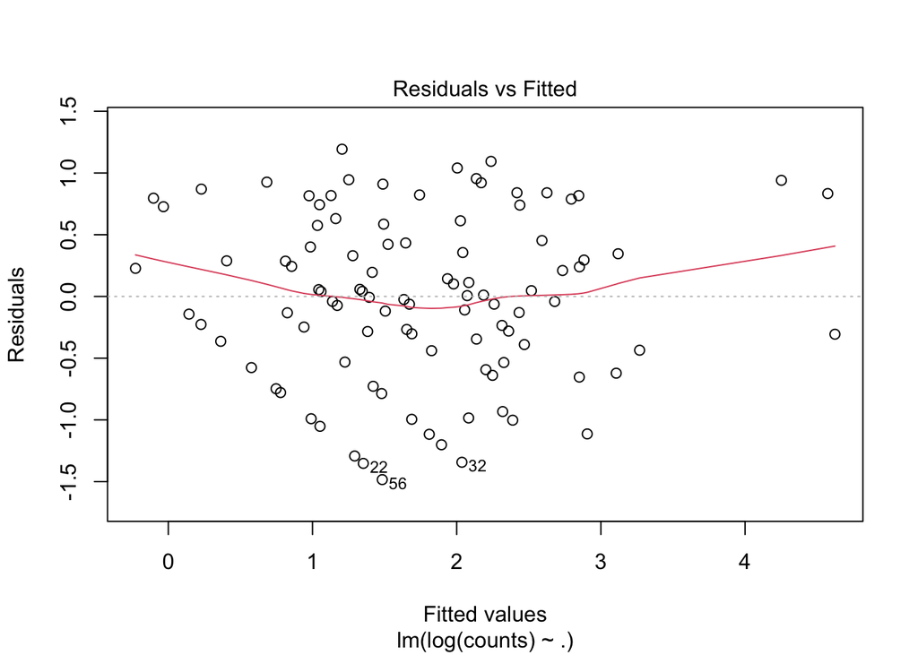

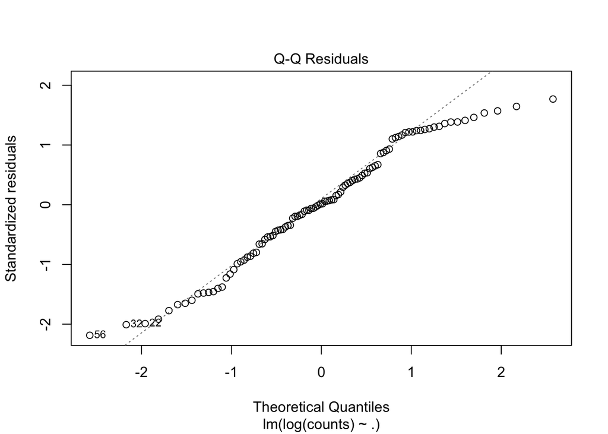

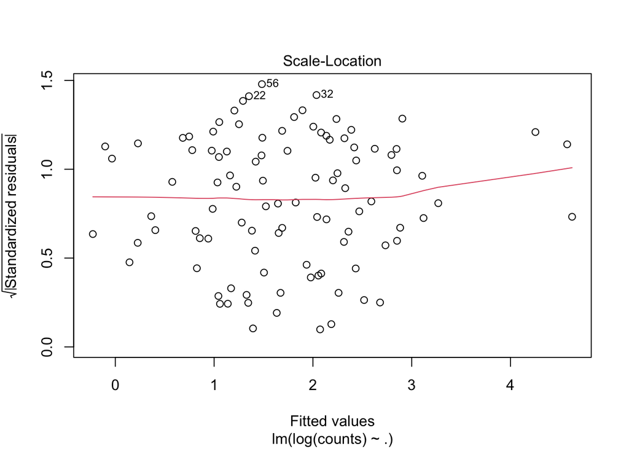

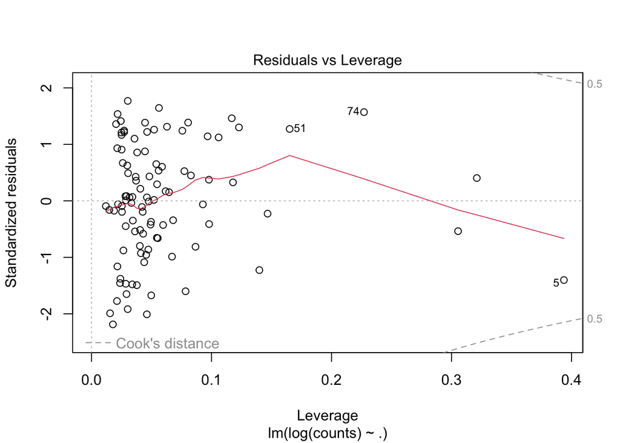

```r
plot(mod1)
```

```r
confint(mod1 ,level = 0.95)
```

```
##                   2.5 %      97.5 %
## (Intercept) -3.39991918  3.35801060
## ndvi         1.70122710  2.86752651
## alt         -0.01915703 -0.01018880
## ants         0.04093820  0.07164163
## humid       -0.45157721  3.04801604
## frog        -0.03608410  0.02446239
```

$H_0: \beta_{n}= 0$ $H_1:$ at least one $\beta_n$ is different from the other.

Our p-value is near zero, so we reject the null hypothesis for which at least one predictor is not significant in our model.

Indeed for example, the altitude and the ants are significant for our model.

# Interaction model

Model with interaction

```r
mod2=lm(log(counts) ~ humid*frog+alt+ants+ndvi, data=liz)
summary(mod2) #model with interaction
```

```
##
## Call:
## lm(formula = log(counts) ~ humid * frog + alt + ants + ndvi,
##     data = liz)
##
## Residuals:
##      Min       1Q   Median       3Q      Max
## -1.48725 -0.39015 -0.00327  0.48927  1.21198
##
## Coefficients:
##               Estimate Std. Error t value Pr(>|t|)
## (Intercept)  42.708738  20.813389   2.052   0.0430 *
## humid       -42.378775  21.223652  -1.997   0.0488 *
## frog         -0.434749   0.208796  -2.082   0.0401 *
## alt          -0.014041   0.002242  -6.264 1.15e-08 ***
## ants          0.057714   0.007633   7.561 2.77e-11 ***
## ndvi          2.229662   0.289982   7.689 1.51e-11 ***
## humid:frog    0.438122   0.212716   2.060   0.0422 *
## ---
## Signif. codes:  0 '***' 0.001 '**' 0.01 '*' 0.05 '.' 0.1 ' ' 1
##
## Residual standard error: 0.6731 on 93 degrees of freedom
## Multiple R-squared:  0.6693, Adjusted R-squared:  0.6479
## F-statistic: 31.36 on 6 and 93 DF,  p-value: < 2.2e-16
```

```r
confint(mod2, level = 0.95) # confidence interval
```

```
##                    2.5 %       97.5 %
## (Intercept)   1.37747265 84.040003318
## humid       -84.52474217 -0.232808198
## frog         -0.84937587 -0.020121653
## alt          -0.01849255 -0.009590173
## ants          0.04255552  0.072871536
## ndvi          1.65381491  2.805510004
## humid:frog    0.01571012  0.860533319
```

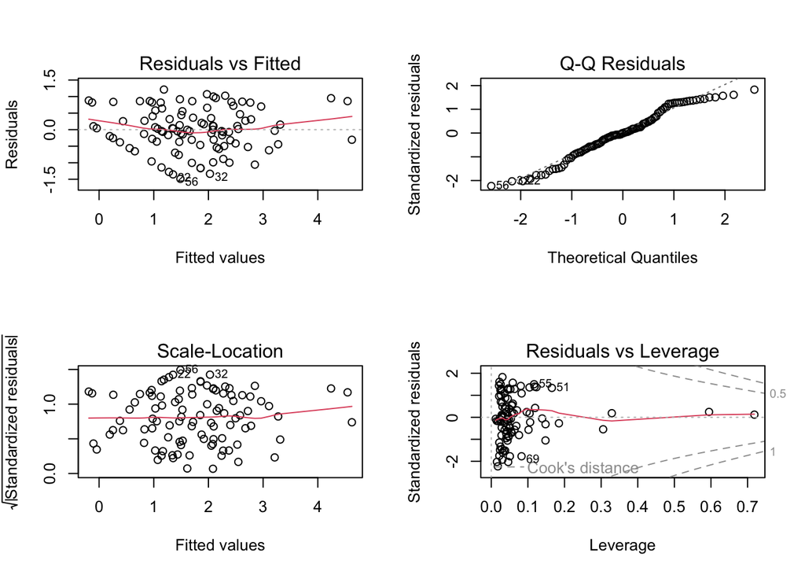

```r
par(mfrow=c(2,2))
plot(mod2)
```

Before interpreting the results, let’s see if the interactions have enough statistical evidence to interact with the response, through an F-test:

```r
anova(lm(log(counts)~humid*frog, data=liz)) #ok for 0.1
```

|  | Df | Sum Sq | Mean Sq | F value | Pr(>F) |
| --- | --- | --- | --- | --- | --- |
| humid | 1 | 1.359913 | 1.359913 | 1.123744 | 0.29177355 |
| frog | 1 | 6.274819 | 6.274819 | 5.185101 | 0.02500121 |
| humid:frog | 1 | 3.584577 | 3.584577 | 2.962061 | 0.08846055 |
| Residuals | 96 | 116.175666 | 1.210163 | NA | NA |

# Interpretations

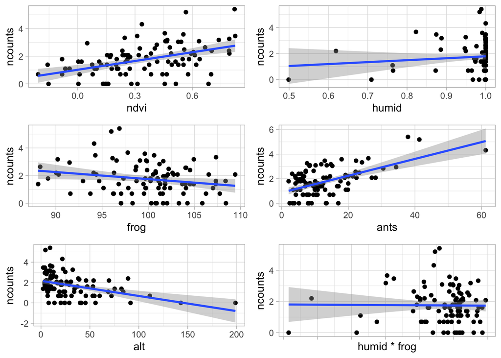

```r
library(ggpubr)
ncounts<-log(liz$counts) #transforming counts in log(counts) to reflect the correct relationship

p1<-ggplot(liz, aes(x=ndvi, y=ncounts)) +
  geom_point() +
  geom_smooth(method="lm", se=TRUE) + theme_light()
p2<-ggplot(liz, aes(x=humid, y=ncounts)) +
  geom_point() +
  geom_smooth(method="lm", se=TRUE) + theme_light()
p3<-ggplot(liz, aes(x=frog, y=ncounts)) +
  geom_point() +
  geom_smooth(method="lm", se=TRUE) + theme_light()
p4<-ggplot(liz, aes(x=ants, y=ncounts)) +
  geom_point() +
  geom_smooth(method="lm", se=TRUE) + theme_light()
p5<-ggplot(liz, aes(x=alt, y=ncounts)) +
  geom_point() +
  geom_smooth(method="lm", se=TRUE) + theme_light()
p6<-ggplot(liz, aes(x=humid*frog, y=ncounts)) +
  geom_point() +
  geom_smooth(method="lm", se=TRUE)+ theme_light()

ggarrange(p1,p2,p3,p4,p5,p6 + rremove("x.text"),
          ncol = 2, nrow = 3)
```

```r
AIC(mod1)
```

```
## [1] 215.8179
```

```r
AIC(mod2)
```

```
## [1] 213.3573
```

```r
# Fit the full model
mod2 <- lm(log(counts) ~ humid*frog + alt + ants + ndvi, data = liz)

# Fit the null model
null_model <- lm(log(counts) ~ 1, data = liz)

# Compare the full model with the null model using anova
anova_results <- anova(null_model, mod2)

# Print the ANOVA results
print(anova_results)
```

```
## Analysis of Variance Table
##
## Model 1: log(counts) ~ 1
## Model 2: log(counts) ~ humid * frog + alt + ants + ndvi
##   Res.Df     RSS Df Sum of Sq      F    Pr(>F)
## 1     99 127.395
## 2     93  42.134  6     85.26 31.365 < 2.2e-16 ***
## ---
## Signif. codes:  0 '***' 0.001 '**' 0.01 '*' 0.05 '.' 0.1 ' ' 1
```

```r
# Extract the F-statistic and p-value from the ANOVA results
f_statistic <- anova_results$"F"[2]
p_value <- anova_results$"Pr(>F)"[2]

cat("F-statistic:", f_statistic, "\n")
```

```
## F-statistic: 31.36475
```

```r
cat("p-value:", p_value, "\n")
```

```
## p-value: 2.386166e-20
```

In this case:

```r
# Summary of the full model
summary_mod2 <- summary(mod2)

# Print the summary
print(summary_mod2)
```

```
##
## Call:
## lm(formula = log(counts) ~ humid * frog + alt + ants + ndvi,
##     data = liz)
##
## Residuals:
##      Min       1Q   Median       3Q      Max
## -1.48725 -0.39015 -0.00327  0.48927  1.21198
##
## Coefficients:
##               Estimate Std. Error t value Pr(>|t|)
## (Intercept)  42.708738  20.813389   2.052   0.0430 *
## humid       -42.378775  21.223652  -1.997   0.0488 *
## frog         -0.434749   0.208796  -2.082   0.0401 *
## alt          -0.014041   0.002242  -6.264 1.15e-08 ***
## ants          0.057714   0.007633   7.561 2.77e-11 ***
## ndvi          2.229662   0.289982   7.689 1.51e-11 ***
## humid:frog    0.438122   0.212716   2.060   0.0422 *
## ---
## Signif. codes:  0 '***' 0.001 '**' 0.01 '*' 0.05 '.' 0.1 ' ' 1
##
## Residual standard error: 0.6731 on 93 degrees of freedom
## Multiple R-squared:  0.6693, Adjusted R-squared:  0.6479
## F-statistic: 31.36 on 6 and 93 DF,  p-value: < 2.2e-16
```

```r
# Extract the t-values and p-values for each coefficient
t_values <- summary_mod2$coefficients[, "t value"]
p_values <- summary_mod2$coefficients[, "Pr(>|t|)"]

cat("t-values:\n")
```

```
## t-values:
```

```r
print(t_values)
```

```
## (Intercept)       humid        frog         alt        ants        ndvi
##    2.051984   -1.996771   -2.082172   -6.264251    7.560863    7.688958
##  humid:frog
##    2.059657
```

```r
cat("p-values:\n")
```

```
## p-values:
```

```r
print(p_values)
```

```
##  (Intercept)        humid         frog          alt         ants         ndvi
## 4.298220e-02 4.877340e-02 4.007311e-02 1.150956e-08 2.772604e-11 1.505283e-11
##   humid:frog
## 4.222611e-02
```

Explanation F-distribution: Used when comparing the full model to the null model. The F-test statistic follows an F-distribution under the null hypothesis. The degrees of freedom for the F-distribution are determined by the number of parameters in the models being compared.

t-distribution: Used for testing individual regression coefficients. The t-test statistic follows a t-distribution under the null hypothesis. The degrees of freedom for the t-distribution are the residual degrees of freedom from the regression model.

Interpretation The F-statistic tests whether the full model provides a significantly better fit to the data compared to the null model. A high F-statistic and a low p-value suggest that the full model significantly improves the fit.

The t-statistics test whether each individual coefficient is significantly different from zero. A high absolute value of the t-statistic and a low p-value suggest that the corresponding predictor is significantly associated with the response variable.